# tree

```python
my_data['Drug'].value_counts()
```

```
Drug
drugY    91
drugX    54
drugA    23
drugC    16
drugB    16
Name: count, dtype: int64
```

```python
X = my_data[['Age', 'Sex', 'BP', 'Cholesterol', 'Na_to_K']].values
X[0:5]
```

```
array([[23, 'F', 'HIGH', 'HIGH', 25.355],
       [47, 'M', 'LOW', 'HIGH', 13.093],
       [47, 'M', 'LOW', 'HIGH', 10.114],
       [28, 'F', 'NORMAL', 'HIGH', 7.798],
       [61, 'F', 'LOW', 'HIGH', 18.043]], dtype=object)
```

```python
from sklearn import preprocessing

le_sex = preprocessing.LabelEncoder()
le_sex.fit(['F', 'M'])
X[:, 1] = le_sex.transform(X[:, 1])

le_BP = preprocessing.LabelEncoder()
le_BP.fit([ 'LOW', 'NORMAL', 'HIGH'])
X[:,2] = le_BP.transform(X[:,2])


le_Chol = preprocessing.LabelEncoder()
le_Chol.fit([ 'NORMAL', 'HIGH'])
X[:,3] = le_Chol.transform(X[:,3])

X[0:5]
```

```
array([[23, 0, 0, 0, 25.355],
       [47, 1, 1, 0, 13.093],
       [47, 1, 1, 0, 10.114],
       [28, 0, 2, 0, 7.798],
       [61, 0, 1, 0, 18.043]], dtype=object)
```

```python
y = my_data['Drug']
y[0:5]
```

```
0    drugY
1    drugC
2    drugC
3    drugX
4    drugY
Name: Drug, dtype: object
```

## Setting up the Decision Tree

```python
from sklearn.model_selection import train_test_split
```

Now **train_test_split** will return 4 different parameters. We will name them:  
X_trainset, X_testset, y_trainset, y_testset  
The **train_test_split** will need the parameters:  
X, y, test_size=0.3, and random_state=3.  
The **X** and **y** are the arrays required before the split, the **test_size** represents the ratio of the testing dataset, and the **random_state** ensures that we obtain the same splits.

```python
X_trainset, X_testset, y_trainset, y_testset = train_test_split(X, y, test_size=0.3, random_state=3)
```

Print the shape of X_trainset and y_trainset. Ensure that the dimensions match.

```python
print('Shape of X training set {}'.format(X_trainset.shape), '&', 'Size of Y training set {}'.format(y_trainset.shape))
```

```
Shape of X training set (140, 5) & Size of Y training set (140,)
```

Print the shape of X_testset and y_testset. Ensure that the dimensions match.

```python
print('Shape of X testing set {}'.format(X_testset.shape),'&',' Size of Y testing set {}'.format(y_testset.shape))
```

```
Shape of X testing set (60, 5) &  Size of Y testing set (60,)
```

## Modeling

We will first create an instance of the **DecisionTreeClassifier** called **drugTree**.  
Inside of the classifier, specify *criterion="entropy"* so we can see the information gain of each node.

```python
drugTree = DecisionTreeClassifier(criterion="entropy", max_depth = 4)
drugTree #It show the default parameters
```

```
DecisionTreeClassifier(criterion='entropy', max_depth=4)
```

```python
drugTree.fit(X_trainset, y_trainset)
```

```
DecisionTreeClassifier(criterion='entropy', max_depth=4)
```

## Prediction

Let's make some **predictions** on the testing dataset and store it into a variable called **predTree**.

```python
predTree = drugTree.predict(X_testset)
```

```python
print(predTree[0:5])
print(y_testset[0:5])
```

```
['drugY' 'drugX' 'drugX' 'drugX' 'drugX']
40     drugY
51     drugX
139    drugX
197    drugX
170    drugX
Name: Drug, dtype: object
```

## Evaluation

Next, let's import **metrics** from sklearn and check the accuracy of our model.

```python
from sklearn import metrics
import matplotlib.pyplot as plt
print("DecisionTrees's Accuracy: ", metrics.accuracy_score(y_testset, predTree))
```

```
DecisionTrees's Accuracy:  0.9833333333333333
```

**Accuracy classification score** computes subset accuracy: the set of labels predicted for a sample must exactly match the corresponding set of labels in y_true.

In multilabel classification, the function returns the subset accuracy. If the entire set of predicted labels for a sample strictly matches with the true set of labels, then the subset accuracy is 1.0; otherwise it is 0.0.

## Visualization

Let's visualize the tree

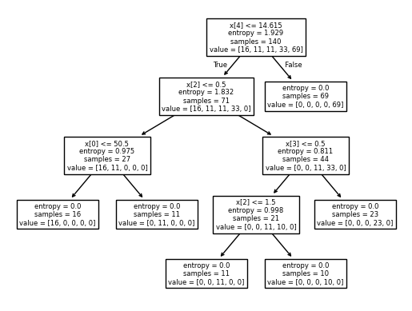

```python
tree.plot_tree(drugTree)
plt.show()
```